# Connectivity of Face-Selective ROIs

Zarrar Shehzad

May 7, 2015

```r
library(plyr)
library(corrplot)
library(RColorBrewer)
library(knitr)
library(ggplot2)
library(reshape)
```

We start by setting some variables and loading in the data. Note that we have 6 ROIs.

```r
setwd("~/Dropbox/Research/facemem/connpaper")

# Make sure to not have any progress when building
prog <- "none"
#prog <- "text"

# We want to select a subset of the extract ROIs for our analyses
subjects <- as.character(as.matrix(read.table("sublist_all.txt")))
runtypes <- c("Questions", "NoQuestions")
conds    <- c("bio", "phys")
snames   <- c("R OFA", "R FFA", "R vATL",
              "L OFA", "L FFA", "L vATL")

load("data/ts_rois_ofa+ffa+vatl.rda")
head(dat$Questions$bio$tb9226)
```

```
##        R OFA  R FFA R vATL   L OFA   L FFA  L vATL
## [1,] -32.481 -10.75 -7.741 -122.39  -31.89 -19.650
## [2,] -34.220  73.99 48.286  -27.73   77.66 -20.558
## [3,] -29.794 133.11 -7.252  -20.76   72.30 -22.293
## [4,]  -2.308 160.15  0.901  -71.95   61.89   6.503
## [5,] -34.542 112.69 51.140 -173.81  -13.09  34.739
## [6,] -34.370  68.84 60.264 -189.08 -118.93 -58.176
```

The output above shows the first 6 time-points across the 6 ROIs for one subject.

# 1 Connectivity: Correlations

## 1.1 Compute the correlations

Here, we will compute the connectivity between every pair of ROIs.

```r
# rmats is
# 2 x 2 x 16 x 6 x 6
# runtypes x conditions x subjects x rois x rois
rmats <- laply(runtypes, function(runtype) {
  cat("Runtype:", runtype, "\n")
  laply(conds, function(cond) {
    cat("- Condition:", cond, "\n")
    laply(subjects, function(subject) {
      # Compute correlation between ROI time-series
      ts.mat    <- dat[[runtype]][[cond]][[subject]]
      r.mat     <- cor(ts.mat)
      return(r.mat)
    }, .progress=prog)
  })
})
```

```
## Runtype: Questions
## - Condition: bio
## - Condition: phys
## Runtype: NoQuestions
## - Condition: bio
## - Condition: phys
```

```r
dimnames(rmats) <- list(runtype=runtypes, condition=conds, subject=subjects,
                        roi=snames, roi=snames)
```

## 1.2 Convert to Z-Scores

Then we convert the connectivity to z-values. This conversion will make the distribution of correlations more normal and will be used in any statistical tests comparing the different conditions.

```r
# r2z <- function(r, n) {
#   #atanh(r)*sqrt(n-3)
#   atanh(r)
# }
r2t <- function(r, kappa) {
  t = r*sqrt((kappa-1)/(1-r*r))
  return(t) # df = kappa-1
}
r2z <- function(r, kappa) {
  r <- as.matrix(r)
  t <- r2t(r, kappa)
  z <- matrix(0, nrow(r), ncol(r))
  z[t>0] <- qt(pt(t[t>0], kappa-1, lower.tail=F), Inf, lower.tail=F)
  z[t<0] <- qt(pt(t[t<0], kappa-1, lower.tail=T), Inf, lower.tail=T)
  z
}

zmats <- laply(runtypes, function(runtype) {
  cat("Runtype:", runtype, "\n")
  laply(conds, function(cond) {
    cat("- Condition:", cond, "\n")
    laply(subjects, function(subject) {
      # Compute correlation between ROI time-series
      ts.mat    <- dat[[runtype]][[cond]][[subject]]
      r.mat     <- cor(ts.mat)
      # Convert correlations to z-stats
      z.mat     <- r2z(r.mat, nrow(ts.mat))
      diag(z.mat) <- 0
      # Return
      return(z.mat)
    }, .progress=prog)
  })
})
```

```
## Runtype: Questions
## - Condition: bio
## - Condition: phys
## Runtype: NoQuestions
## - Condition: bio
## - Condition: phys
```

```r
dimnames(zmats) <- dimnames(rmats)
```

## 1.3 Average Connectivity

We can now compute the average connectivity (collapsing across subjects).

```r
ave.rmat <- apply(rmats, c(1,2,4,5), function(x) tanh(mean(atanh(x))))
overall.ave.rmat <- apply(rmats, c(4,5), function(x) tanh(mean(atanh(x))))
```

### 1.3.1 Average Connectivity Collapsed Across RunTypes and Conditions

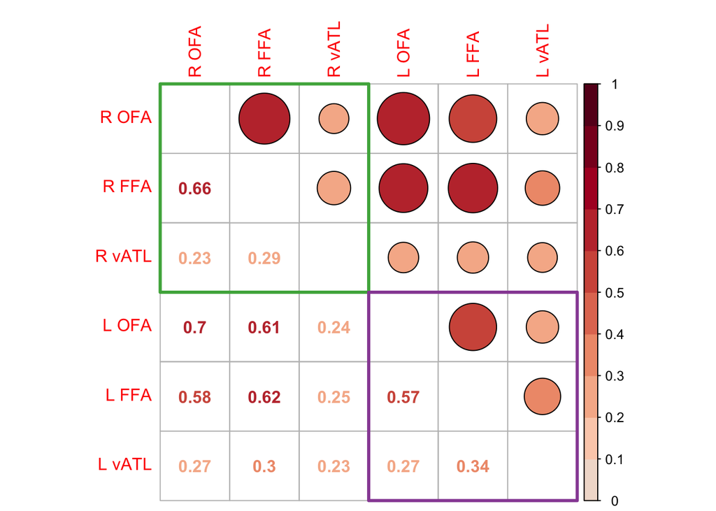

```r
cols <- rev(colorRampPalette(brewer.pal(10, "RdBu"))(20))
#corrplot(overall.ave.rmat, method="circle", diag=F, outline=T, col=cols,
#         cl.lim=c(0,1), cl.length=length(cols)/2+1, addgrid.col="grey")
corrplot.mixed(overall.ave.rmat, lower="number", upper="circle", diag='n',
               outline=T, col=cols, tl.pos="lt",
               cl.lim=c(0,1), cl.length=length(cols)/2+1, addgrid.col="grey")
## highlight the within-hemisphere connectivity
n <- length(snames)
mat <- cbind(c(0,3), n - c(0,3),
             c(3,6), n - c(3,6)) + 0.5
rect(mat[1, 1], mat[1, 2], mat[1, 3], mat[1, 4],
     border = brewer.pal(9,"Set1")[3], lwd = 3, lty=1)
rect(mat[2, 1], mat[2, 2], mat[2, 3], mat[2, 4],
     border = brewer.pal(9,"Set1")[4], lwd = 3, lty=1)
```

```r
#corrRect(c(3,1,2), col=brewer.pal(9,"Set1")[3], lwd=3)
```

### 1.3.2 Average Connectivity by each RunType & Condition

We can now drill down and look at the connectivity for each task and each condition.

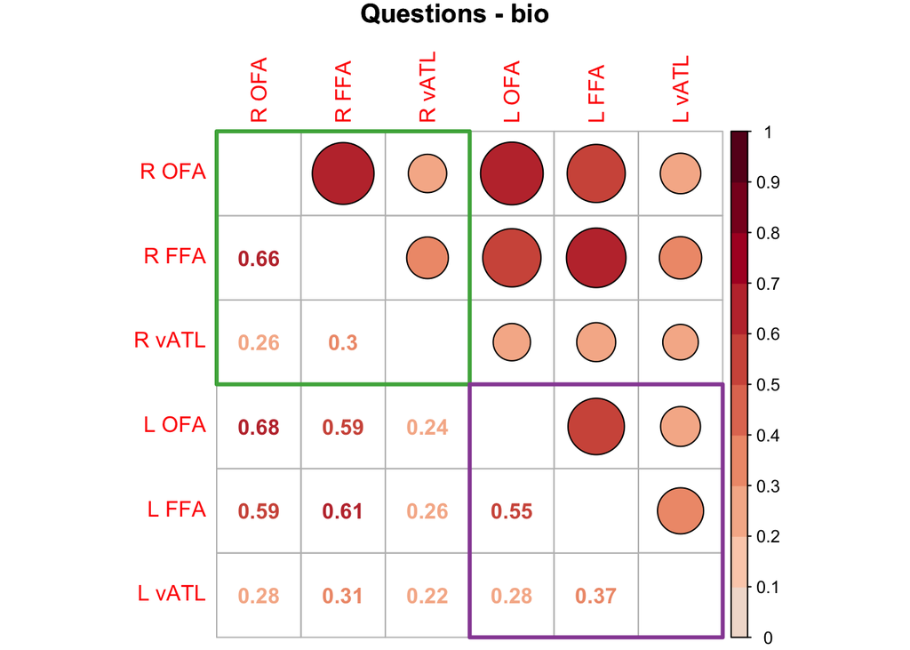

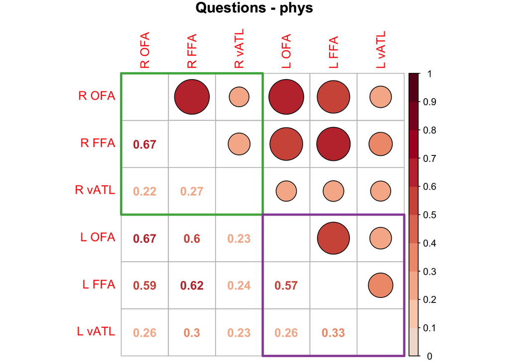

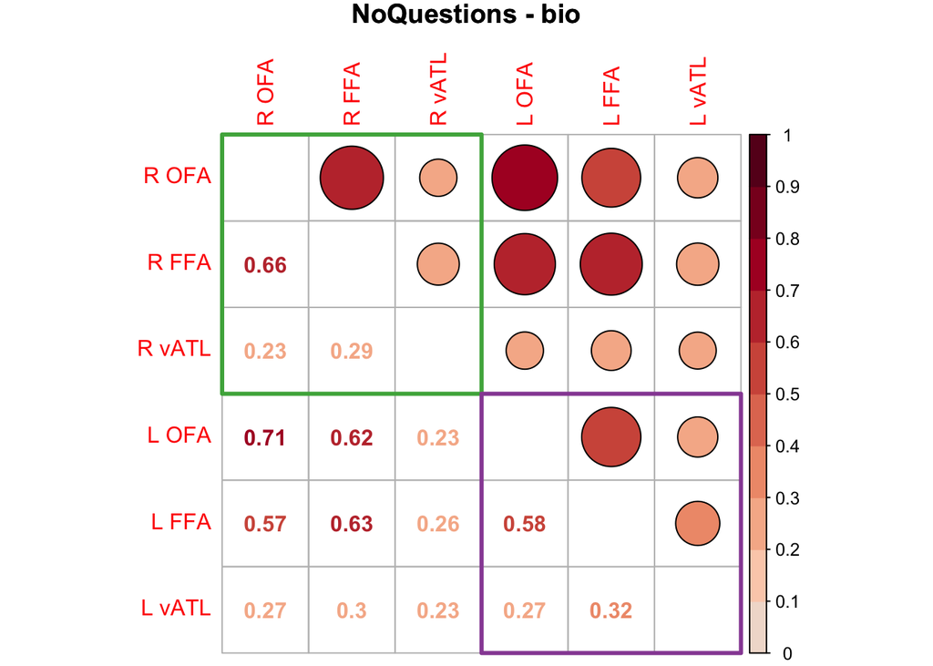

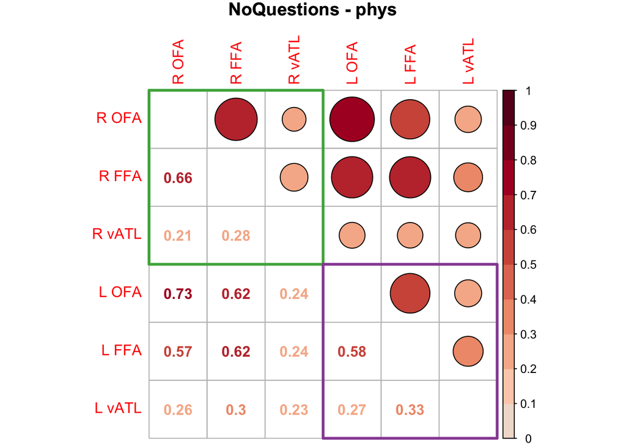

```r
for (ri in 1:2) {
  for (ci in 1:2) {
    #corrplot(ave.rmat[ri,ci,,], method="circle", diag=F, outline=T, col=cols,
    #     cl.lim=c(0,1), cl.length=length(cols)/2+1, addgrid.col="grey",
    #     mar=c(0,0,1,0), title=sprintf("%s - %s", runtypes[ri], conds[ci]))
    corrplot.mixed(ave.rmat[ri,ci,,], lower="number", upper="circle", diag='n',
                   outline=T, col=cols, tl.pos="lt",
                   cl.lim=c(0,1), cl.length=length(cols)/2+1, addgrid.col="grey",
                   mar=c(0,0,1,0), title=sprintf("%s - %s", runtypes[ri], conds[ci]))

    n <- length(snames)
    mat <- cbind(c(0,3), n - c(0,3),
                 c(3,6), n - c(3,6)) + 0.5
    rect(mat[1, 1], mat[1, 2], mat[1, 3], mat[1, 4],
         border = brewer.pal(9,"Set1")[3], lwd = 3, lty=1)
    rect(mat[2, 1], mat[2, 2], mat[2, 3], mat[2, 4],
         border = brewer.pal(9,"Set1")[4], lwd = 3, lty=1)
  }
}
```

## 1.4 Differences between Bio and Phys Conditions

We can take the difference in the connectivity values between bio and phys.

### 1.4.1 Average Difference

Here we take the average differences.

Bio > Phys : Red. <sub>~</sub> Phys > Bio : Blue.

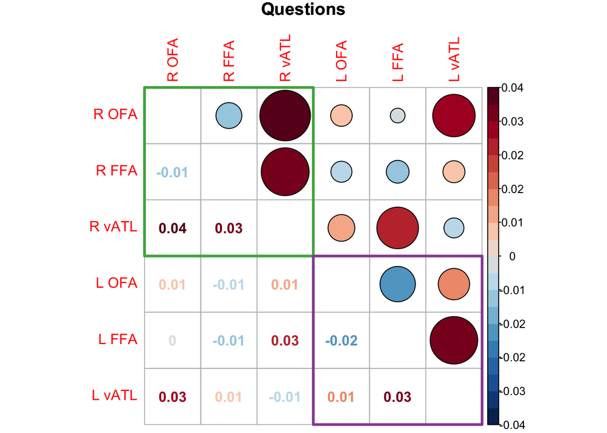

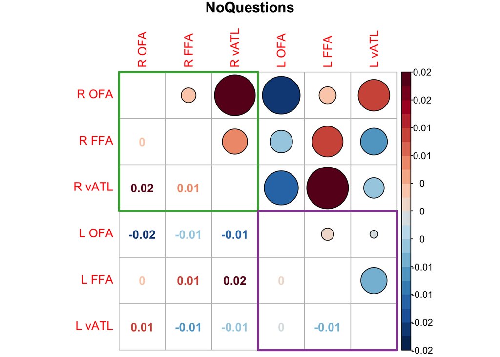

```r
for (ri in 1:2) {
  d <- ave.rmat[ri,1,,] - ave.rmat[ri,2,,]
  rang <- rep(max(abs(d)), 2) * c(-1,1)
  corrplot.mixed(d, lower="number", upper="circle", diag='n', is.corr=F,
                 outline=T, col=cols, tl.pos="lt",
                 cl.lim=rang, cl.length=length(cols)/2+1, addgrid.col="grey",
                 mar=c(0,0,1,0), title=runtypes[ri])
  n <- length(snames)
  mat <- cbind(c(0,3), n - c(0,3),
               c(3,6), n - c(3,6)) + 0.5
  rect(mat[1, 1], mat[1, 2], mat[1, 3], mat[1, 4],
       border = brewer.pal(9,"Set1")[3], lwd = 3, lty=1)
  rect(mat[2, 1], mat[2, 2], mat[2, 3], mat[2, 4],
       border = brewer.pal(9,"Set1")[4], lwd = 3, lty=1)
}
```

### 1.4.2 Significant Differences?

#### 1.4.2.1 Wilcox Signed Rank Test with r => Z vals

I am using the non-parametric wilcox sign rank test. In the end, this approach seems to be fairly similar to using the parametric t-test (see below).

For the Questions run, we find that

- R vATL - R OFA was significantly greater for bio vs phys (p < 0.05).
- R vATL - R FFA was marginally greater for bio vs phys (p = 0.08).
- L vATL - L FFA was also marginally greater for bio vs phys (p = 0.1)

Nothing was found for the No Questions run.

```r
pMats <- aaply(zmats, c(1,4,5), function(x) {
  if (all(x==0)) {
    return(0)
  } else {
    return(wilcox.test(x[1,], x[2,], paired=T)$p.value)
  }
})
cat("Questions\n")
round(pMats[1,,], 2)
cat("No Questions\n")
round(pMats[2,,], 2)
```

```
## Questions
```

```
##         roi
## roi      R OFA R FFA R vATL L OFA L FFA L vATL
##   R OFA   0.00  0.50   0.04  0.78  0.82   0.35
##   R FFA   0.50  0.00   0.08  0.98  0.82   0.98
##   R vATL  0.04  0.08   0.00  0.60  0.16   0.63
##   L OFA   0.78  0.98   0.60  0.00  0.86   0.56
##   L FFA   0.82  0.82   0.16  0.86  0.00   0.10
##   L vATL  0.35  0.98   0.63  0.56  0.10   0.00
```

```
## No Questions
```

```
##         roi
## roi      R OFA R FFA R vATL L OFA L FFA L vATL
##   R OFA   0.00  0.82   0.19  0.18  0.98   0.30
##   R FFA   0.82  0.00   0.71  0.63  0.50   0.67
##   R vATL  0.19  0.71   0.00  0.56  0.27   0.90
##   L OFA   0.18  0.63   0.56  0.00  1.00   0.46
##   L FFA   0.98  0.50   0.27  1.00  0.00   0.67
##   L vATL  0.30  0.67   0.90  0.46  0.67   0.00
```

#### 1.4.2.2 T-Test with r => Z vals

These are the results when using a t-statistic. As you can see the wilcox test, might be more robust in the sense that we get more significant results in some connections of interest with the vATL.

```r
pMats <- aaply(zmats, c(1,4,5), function(x) {
  if (all(x==0)) {
    return(0)
  } else {
    return(t.test(x[1,], x[2,], paired=T)$p.value)
  }
})
cat("Questions\n")
round(pMats[1,,], 2)
cat("No Questions\n")
round(pMats[2,,], 2)
```

```
## Questions
```

```
##         roi
## roi      R OFA R FFA R vATL L OFA L FFA L vATL
##   R OFA   0.00  0.74   0.05  0.56  0.95   0.30
##   R FFA   0.74  0.00   0.08  0.92  0.88   0.70
##   R vATL  0.05  0.08   0.00  0.53  0.11   0.69
##   L OFA   0.56  0.92   0.53  0.00  0.46   0.57
##   L FFA   0.95  0.88   0.11  0.46  0.00   0.15
##   L vATL  0.30  0.70   0.69  0.57  0.15   0.00
```

```
## No Questions
```

```
##         roi
## roi      R OFA R FFA R vATL L OFA L FFA L vATL
##   R OFA   0.00  0.73   0.20  0.11  0.80   0.34
##   R FFA   0.73  0.00   0.62  0.75  0.43   0.63
##   R vATL  0.20  0.62   0.00  0.48  0.29   0.81
##   L OFA   0.11  0.75   0.48  0.00  0.86   0.99
##   L FFA   0.80  0.43   0.29  0.86  0.00   0.71
##   L vATL  0.34  0.63   0.81  0.99  0.71   0.00
```

#### 1.4.2.3 Wilcox Test with r vals

However, if I use only the correlations and not the Fischer Z-transformed correlations, then I get some almost significant differences amongst the right hemisphere ROIs (but only for the Questions task).

```r
pMats <- aaply(rmats, c(1,4,5), function(x) {
  if (all(x==1)) {
    return(0)
  } else {
    return(wilcox.test(x[1,], x[2,], paired=T)$p.value)
  }
})

cat("Questions\n")
round(pMats[1,,], 2)
#kable(pMats[1,,], format="html", digits=2, caption="Questions")

cat("NoQuestions\n")
round(pMats[2,,], 2)
#kable(pMats[2,,], format="html", digits=2, caption="Passitve Viewing")
```

```
## Questions
```

```
##         roi
## roi      R OFA R FFA R vATL L OFA L FFA L vATL
##   R OFA   0.00  0.50   0.06  0.78  0.78   0.35
##   R FFA   0.50  0.00   0.08  0.90  0.63   0.98
##   R vATL  0.06  0.08   0.00  0.60  0.16   0.53
##   L OFA   0.78  0.90   0.60  0.00  0.60   0.67
##   L FFA   0.78  0.63   0.16  0.60  0.00   0.14
##   L vATL  0.35  0.98   0.53  0.67  0.14   0.00
```

```
## NoQuestions
```

```
##         roi
## roi      R OFA R FFA R vATL L OFA L FFA L vATL
##   R OFA   0.00  0.82   0.21  0.09  0.98   0.43
##   R FFA   0.82  0.00   0.67  0.56  0.53   0.71
##   R vATL  0.21  0.67   0.00  0.60  0.30   0.90
##   L OFA   0.09  0.56   0.60  0.00  0.78   0.53
##   L FFA   0.98  0.53   0.30  0.78  0.00   0.78
##   L vATL  0.43  0.71   0.90  0.53  0.78   0.00
```

# 2 Effect of # of Time-Points

I wonder if this difference in using the z versus r values has to do with the different concatenated condition time-series having different # of time-points. So here I try to explore that issue by looking at any differences between the conditions in the number of time-points.

```r
# Collect all the ns
nmats <- laply(runtypes, function(runtype) {
  cat("Runtype:", runtype, "\n")
  laply(conds, function(cond) {
    cat("- Condition:", cond, "\n")
    laply(subjects, function(subject) {
      # Compute correlation between ROI time-series
      ts.mat    <- dat[[runtype]][[cond]][[subject]]
      nrow(ts.mat)
    }, .progress=prog)
  })
})
dimnames(nmats) <- list(runtype=runtypes, condition=conds, subject=subjects)

# See if there is any significant difference in the ns
# using both the wilcox test and t-test
ndiffs1 <- aaply(nmats, 1, function(x) wilcox.test(x[1,], x[2,], paired=T)$p.value)
ndiffs2 <- aaply(nmats, 1, function(x) t.test(x[1,], x[2,], paired=T)$p.value)

# Get the average differences
naves <- aaply(nmats, 1, function(x) mean(x[1,] - x[2,]))
```

```
## Runtype: Questions
## - Condition: bio
## - Condition: phys
## Runtype: NoQuestions
## - Condition: bio
## - Condition: phys
```

Unfortunately, it appears that there are significant differences in the length of the conditions in the condition as seen below.

```r
cat("wilcox test\n")
print(ndiffs1)
cat("t-test\n")
print(ndiffs2)
```

```
## wilcox test
```

```
##   Questions NoQuestions
##     0.08132     0.30996
```

```
## t-test
```

```
##   Questions NoQuestions
##      0.0498      0.1547
```

And it seems that on average for a given subject there are ~9 more seconds in the bio condition for the Questions run and on average ~5 more seconds in the bio condition for the No Questions condition. This might explain why using the raw r-values may lead to significant differences since it’s confounded by the number of time-points.

```r
print(naves)
```

```
##   Questions NoQuestions
##       9.375       4.938
```

To understand this more. Let’s plot the histogram for the total time in each condition by runtypes, and then plot the difference between the two conditions.

```
## stat_bin: binwidth defaulted to range/30. Use 'binwidth = x' to adjust this.
## stat_bin: binwidth defaulted to range/30. Use 'binwidth = x' to adjust this.
## stat_bin: binwidth defaulted to range/30. Use 'binwidth = x' to adjust this.
## stat_bin: binwidth defaulted to range/30. Use 'binwidth = x' to adjust this.
```

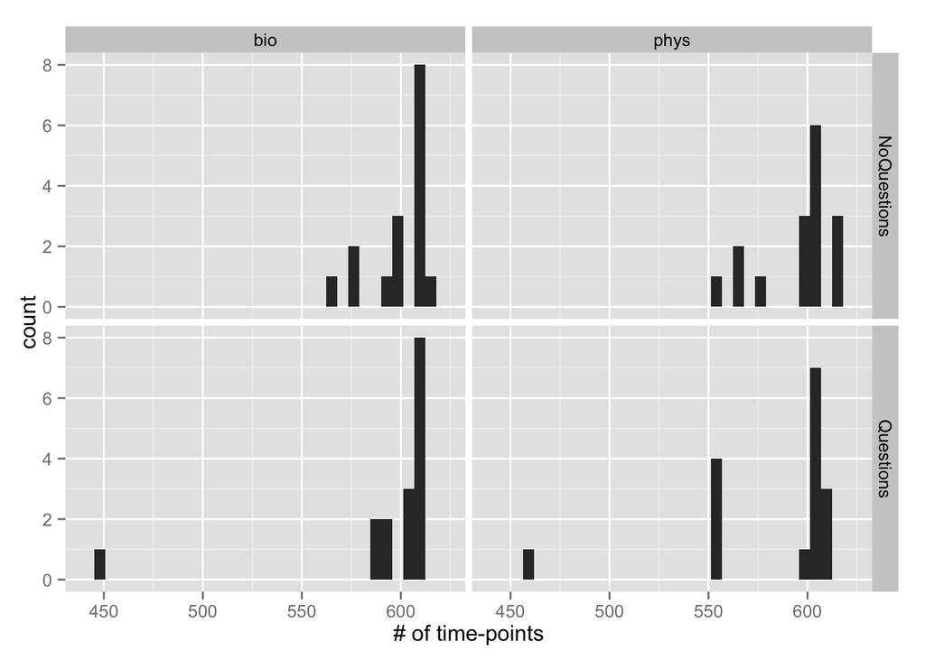

```r
ndf <- melt(nmats)
ggplot(ndf, aes(x=value)) +
  geom_histogram() +
  facet_grid(runtype ~ condition) +
  xlab("# of time-points")
```

It appears that there is one participant who has a low number of time-points. I think this might be the subject for whom we only collected 3 runs of data. But note there doesn’t appear to be a big difference between conditions for this subject.

Why don’t we now look at the histogram of the differences below. This shows more clearly that most of our subjects have more time-points for the bio than the phys condition. Values greater than 0 mean bio > phys.

```
## stat_bin: binwidth defaulted to range/30. Use 'binwidth = x' to adjust this.
## stat_bin: binwidth defaulted to range/30. Use 'binwidth = x' to adjust this.
```

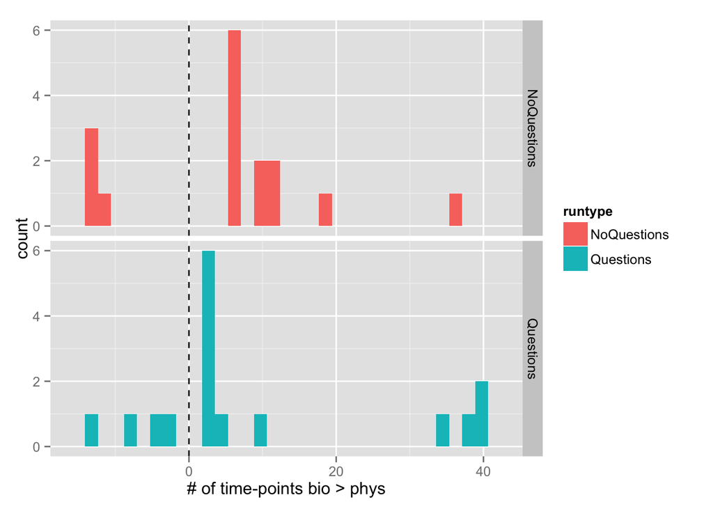

```r
ndf <- melt(nmats[,1,]-nmats[,2,])
ggplot(ndf, aes(x=value, fill=runtype)) +
  geom_vline(xintercept=0, linetype=2) +
  geom_histogram() +
  facet_grid(runtype ~ .) +
  xlab("# of time-points bio > phys")
```

## 2.1 Double Check with Timing Files

So this is turning into a real investigation. We can double check the more original timing files and see if the jitter is properly randomized. This would be a sanity check that I created these files in the proper manner. Also in this case we can get the durations for each trial.

```r
scandat <- ldply(runtypes, function(runtype) {
  #cat(runtype, "\n")
  tab <- ldply(subjects, function(subject) {
    #cat("-", subject, "\n")
    indir  <- "~/Dropbox/Research/facemem/data/ts"
    infile <- sprintf("%s/%s_%s_timing.txt", indir, subject, runtype)
    tab    <- read.csv(infile)
    cbind(subject=subject, tab)
  })
  cbind(runtype=runtype, tab)
})
head(scandat)
```

```
##     runtype subject run trial condition onset duration per.run.onset
## 1 Questions  tb9226   1     1       bio 11.02    17.02         11.02
## 2 Questions  tb9226   1     2       bio 28.04    18.02         28.04
## 3 Questions  tb9226   1     3       bio 46.06    14.02         46.06
## 4 Questions  tb9226   1     4       bio 60.08    17.02         60.08
## 5 Questions  tb9226   1     5      phys 77.09    17.02         77.09
## 6 Questions  tb9226   1     6      phys 94.12    15.01         94.12
```

```
## stat_bin: binwidth defaulted to range/30. Use 'binwidth = x' to adjust this.
## stat_bin: binwidth defaulted to range/30. Use 'binwidth = x' to adjust this.
## stat_bin: binwidth defaulted to range/30. Use 'binwidth = x' to adjust this.
## stat_bin: binwidth defaulted to range/30. Use 'binwidth = x' to adjust this.
```

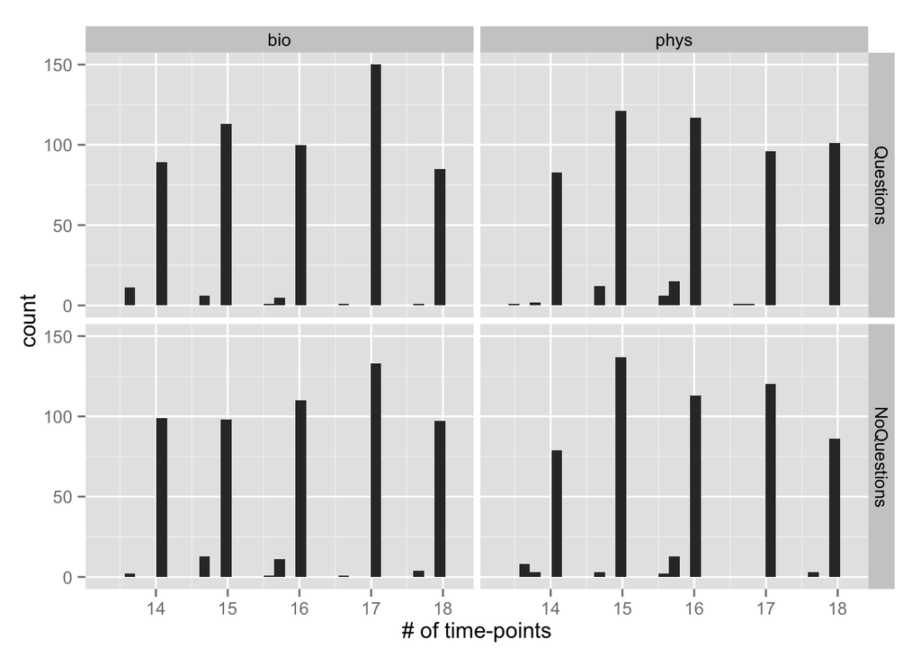

```r
ggplot(scandat, aes(x=duration)) +
  geom_histogram() +
  facet_grid(runtype ~ condition) +
  xlab("# of time-points")
```

For the remainder, I’ll focus mainly on the Questions run and try to see if I can reproduce the significant difference in # of time-points between conditions.

### 2.1.1 Overall Difference (not significant)

If I collapse across subjects and compare the duration of each trial between conditions, I don’t find a significant difference.

```r
qscandat <- subset(scandat, runtype=="Questions")
# T-Test
t.test(duration ~ condition, data=qscandat)
```

```
##
##  Welch Two Sample t-test
##
## data:  duration by condition
## t = 0.3062, df = 1116, p-value = 0.7595
## alternative hypothesis: true difference in means is not equal to 0
## 95 percent confidence interval:
##  -0.1337  0.1831
## sample estimates:
##  mean in group bio mean in group phys
##              16.01              15.98
```

```r
# Anova (to account for repeated measures)
summary(aov(duration ~ condition + Error(subject), data=qscandat))
```

```
##
## Error: subject
##           Df Sum Sq Mean Sq F value Pr(>F)
## condition  1 0.0011 0.00113     0.1   0.75
## Residuals 14 0.1536 0.01097
##
## Error: Within
##             Df Sum Sq Mean Sq F value Pr(>F)
## condition    1      0   0.171    0.09   0.76
## Residuals 1101   2034   1.847
```

### 2.1.2 Number of Trials (significantish)

When looking at the number of trials, we see the first three subjects have more bio trials (note that this is due to the disdaqs issue). It’s interesting that the difference between just those three subjects can lead to an almost significant difference.

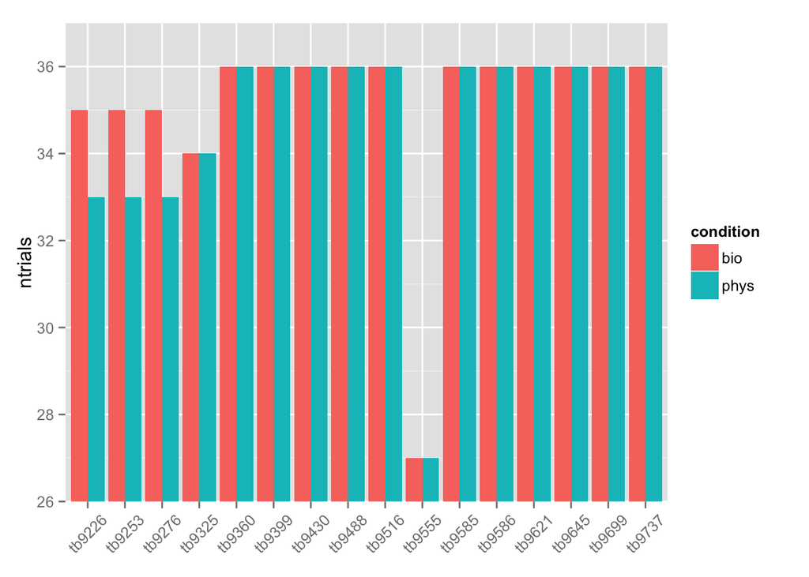

```r
tmp <- ddply(qscandat, .(subject, condition), function(x) c(ntrials=nrow(x)))

# Plot
ggplot(tmp, aes(x=subject, y=ntrials, fill=condition)) +
  geom_bar(position="dodge", stat="identity") +
  coord_cartesian(ylim = range(tmp$ntrials) + c(-1,1))  +
  theme(
    axis.title.x = element_blank(),
    axis.text.x = element_text(angle=45, vjust=0.5)
  )
```

```r
# Table
ddply(tmp, .(subject), function(x) c(mean=mean(x$ntrials), diff=x$ntrials[1] - x$ntrials[2]))
```

```
##    subject mean diff
## 1   tb9226   34    2
## 2   tb9253   34    2
## 3   tb9276   34    2
## 4   tb9325   34    0
## 5   tb9360   36    0
## 6   tb9399   36    0
## 7   tb9430   36    0
## 8   tb9488   36    0
## 9   tb9516   36    0
## 10  tb9555   27    0
## 11  tb9585   36    0
## 12  tb9586   36    0
## 13  tb9621   36    0
## 14  tb9645   36    0
## 15  tb9699   36    0
## 16  tb9737   36    0
```

```r
# Significance Test (almost)
t.test(ntrials ~ condition, paired=T, data=tmp)
```

```
##
##  Paired t-test
##
## data:  ntrials by condition
## t = 1.861, df = 15, p-value = 0.08253
## alternative hypothesis: true difference in means is not equal to 0
## 95 percent confidence interval:
##  -0.05461  0.80461
## sample estimates:
## mean of the differences
##                   0.375
```

I should note that if I even the number of trials between the two conditions, then I don’t get any significant differences here. So it’s likely that the differences here are driven by those first 3 subjects who have 2 more trials each with the bio vs phys condition.

With that said, it does appear that there are large differences in total duration of each condition for other subjects like the fourth one. For the fifth subject, the difference is flipped with more time spent during phys trials. In general, the differences for each subject between the two conditions is small.

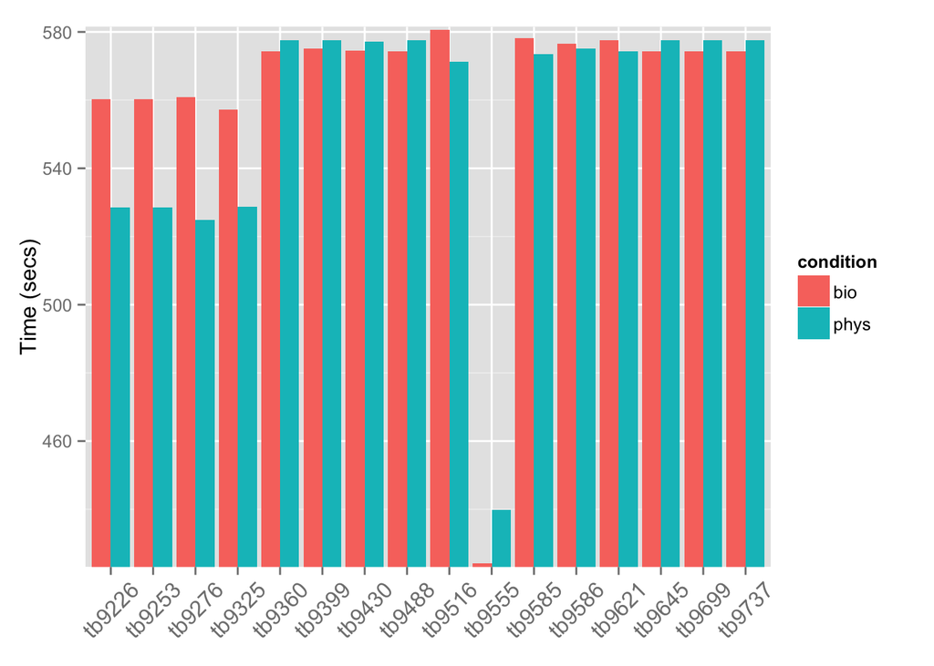

```r
# Sum up all the trial durations
tmp <- ddply(qscandat, .(subject, condition), function(x) c(total.duration=sum(x$duration)))
ggplot(tmp, aes(x=subject, y=total.duration, fill=condition)) +
  geom_bar(position="dodge", stat="identity") +
  coord_cartesian(ylim = range(tmp$total.duration) + c(-1,1)) +
  ylab("Time (secs)") +
  theme(
    axis.title.x = element_blank(),
    axis.text.x = element_text(angle=45, vjust=0.5, size=12)
  )
```

```r
# Significance
t.test(total.duration ~ condition, paired=T, data=tmp)
```

```
##
##  Paired t-test
##
## data:  total.duration by condition
## t = 1.726, df = 15, p-value = 0.1049
## alternative hypothesis: true difference in means is not equal to 0
## 95 percent confidence interval:
##  -1.613 15.337
## sample estimates:
## mean of the differences
##                   6.862
```

```r
# Display each subject's time
ddply(tmp, .(subject), function(x) {
  round(c(bio=x$total[1], phys=x$total[2], diff=x$total[1]-x$total[2]), 1)
})
```

```
##    subject   bio  phys  diff
## 1   tb9226 560.2 528.6  31.6
## 2   tb9253 560.2 528.6  31.6
## 3   tb9276 561.0 524.9  36.1
## 4   tb9325 557.2 528.6  28.6
## 5   tb9360 574.2 577.5  -3.3
## 6   tb9399 575.2 577.5  -2.3
## 7   tb9430 574.6 577.1  -2.6
## 8   tb9488 574.3 577.5  -3.2
## 9   tb9516 580.6 571.2   9.4
## 10  tb9555 424.1 439.7 -15.7
## 11  tb9585 578.3 573.4   4.8
## 12  tb9586 576.5 575.2   1.3
## 13  tb9621 577.5 574.3   3.2
## 14  tb9645 574.2 577.5  -3.2
## 15  tb9699 574.2 577.5  -3.3
## 16  tb9737 574.3 577.5  -3.2
```

### 2.1.4 Other Factors

One last thing to note is that for getting my time-series for connectivity, I shift the trial data that I extract by 2 time-points to account for the HRF delay. This means that for trials at the end of each run, the amount we extract for that trial will be made shorter. This is only a problem if there is an imbalance in which condition comes at the end of each run. Alas it seems there is a slight imbalance with physical trials coming more often at the end of each run.

```r
cat("Number of trials at the end of the run\n")
table(qscandat[c(diff(qscandat$run)!=0, F),]$condition)
```

```
## Number of trials at the end of the run
```

```
##
##  bio phys
##   24   38
```

# 3 Final Notes

For connectivity, we can restrict the length of time to some minimum value, which might make more sense anyway. Although I just realized that there could be two issues. First, the trial lengths could differ. Second, the number of trials in each condition could differ.